# Statistical Learning: Nitrogen Oxides, Car Seats, and Predictions

10466486

In this markdown using R version 4.2.1 (2022-06-23), we will use methods in statistical learning to answer questions posed for two different data sets. The data sets can both be found in the package ISLR2 and will differ on the nature of their problems. We will switch between explaining the results and the coding done to arrive at the results.

The first problem is a regression problem that seeks to find out how a set of potential variables will affect the continuous variable of nitrogen oxide concentration. The second problem is a classification problem that seeks to find out how a different set of potential variables will affect the categorical variable of whether car seats are place in a *“good”* or *“bad”* location.

To explore these problems, I will want to first focus on building the best model for predicting data before answering the problem. The best model will be determined by cross-validations between different models.

Below are all the packages we will be using for both the regression and the classification problem.

```r
# Load packages
library(ISLR2)    # contains data sets
library(corrplot) # for creating correlation plots
library(caret)    # for cross-validation
library(car)      # for residual plots
library(effects)  # for effect plots
```

# 1 The Regression Problem

The first problem involves exploring how areas characterized by 4 different factors affect the nitrogen oxide level in certain areas. The motivation behind answering this problem is that nitrogen oxides are a family of poisonous gases. By exploring different factors we will be a able to predict areas that are likely to have higher level of nitrogen oxide and areas that are more suitable for future residence.

## 1.1 Load data

Factors:

- *nox* - nitrogen oxides concentration (parts per 10 million)
- *age* - owner-occupied units built prior to 1940 (%)
- *dis* - weighted mean distance to five Boston employment centres
- *lstat* - people of lower education or manual labour jobs living in area (%)
- *medv* - median value of owner-occupied homes (in 1000 dollars)

```r
# Loading the data
regression_data <- Boston[ ,c(5, 7, 8, 12, 13)] # we want to take all rows and certain columns
```

| nox | age | dis | lstat | medv |
| --- | --- | --- | --- | --- |
| 0.538 | 65.2 | 4.09 | 4.98 | 24 |
| 0.469 | 78.9 | 4.9671 | 9.14 | 21.6 |
| 0.469 | 61.1 | 4.9671 | 4.03 | 34.7 |
| 0.458 | 45.8 | 6.0622 | 2.94 | 33.4 |
| 0.458 | 54.2 | 6.0622 | 5.33 | 36.2 |
| 0.458 | 58.7 | 6.0622 | 5.21 | 28.7 |
| 0.524 | 66.6 | 5.5605 | 12.43 | 22.9 |
| 0.524 | 96.1 | 5.9505 | 19.15 | 27.1 |
| 0.524 | 100 | 6.0821 | 29.93 | 16.5 |
| 0.524 | 85.9 | 6.5921 | 17.1 | 18.9 |

[output cut: 496 more lines]

## 1.2 Exploring variables

I want to know out of the factors listed above whether they are worth considering when building the model. This can be done by assuming a linear relationship and exploring whether they will have an effect.

From the results of the plot below we can see that all the variables have a correlation. That means a change in the factor will also indicate change in the nitrogen oxide levels (above 0.3 or below -0.3). *Age* and *lstat* have a positive correlation so I expect them to increase with *nox*. *Dis* and *medv* has a negative correlation so I expect them to decrease with *nox*. I want to consider using all the variables when constructing my model.

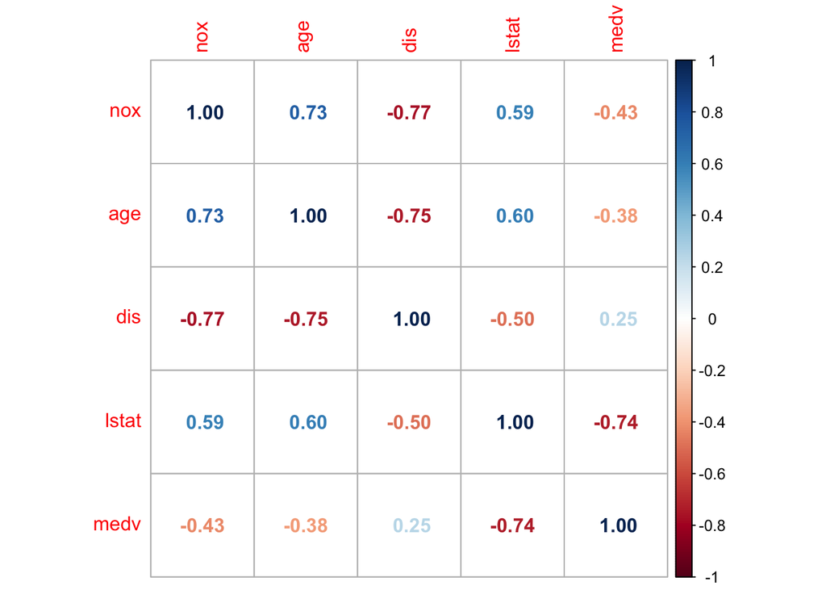

```r
# Correlation plots
corrplot(cor(regression_data), method = 'number')
```

By building a linear model we can further explore the significance of each variable. All variables are significantly different from the constant (p < 0.5) except for *lstat*. However, because the p-value for *lstat* is not too far off and earlier we saw that there is a correlation between *lstat* and *nox* I still want to use it to build my models.

```r
# Linear model
lin_model <- lm(nox ~ ., data = regression_data)

# Model summary
summary(lin_model)$coefficients # take coefficients only
```

```
##                 Estimate   Std. Error    t value     Pr(>|t|)
## (Intercept)  0.615633312 0.0257136004  23.941934 5.108833e-85
## age          0.001023238 0.0001704874   6.001841 3.745886e-09
## dis         -0.027866281 0.0021225684 -13.128567 4.772568e-34
## lstat        0.001308053 0.0007187217   1.819971 6.935997e-02
## medv        -0.001859683 0.0004797281  -3.876535 1.200549e-04
```

## 1.3 Building Linear Models

Now that we know the variables to use we can start building our models.

### 1.3.1 Cross-validation

I used a backward step-wise selection method to construct models, which simply means starting to build with the most complex model (with the most inputs) and moving into simpler linear models.

I used K-fold validation (K = 10 folds) as the method to compare different models. This means the model will be trained with all the data except for 10 random data points, and then tested with the separated 10 points. A larger K value wasn’t chosen because I wanted to balance between taking away too much data for training and still keep enough data for testing.

```r
set.seed(1) # controls for random elements to the function

# Set training method
k_fold <- trainControl(method = 'cv', number = 10)

# K-fold validation
# Linear model with all inputs
lin_model_train <- train(nox ~.,
                         data = regression_data,
                         method = 'lm',
                         trControl = k_fold)
# Linear model with 3 inputs
lin_model_train_1 <- train(nox ~ dis + age + lstat,
                           data = regression_data,
                           method = 'lm',
                           trControl = k_fold)
# Linear model with 2 input
lin_model_train_2 <- train(nox ~ dis + age,
                           data = regression_data,
                           method = 'lm',
                           trControl = k_fold)
# Linear model with 1 input
lin_model_train_3 <- train(nox ~ dis,
                           data = regression_data,
                           method = 'lm',
                           trControl = k_fold)

# Compare results of k-fold
lin_k_fold <- rbind(lin_model_train$results, # binds results into a data frame
                    lin_model_train_1$results,
                    lin_model_train_2$results,
                    lin_model_train_3$results)
```

From the residual mean squared error (RMSE) and the $R^2$ we can see that as we move down into simpler models the scores become worst. The RMSE becomes higher indicating greater levels of error, the $R^2$ become lower to indicate that less variance is being explained the simpler the model.

```
##   intercept       RMSE  Rsquared        MAE      RMSESD RsquaredSD       MAESD
## 1      TRUE 0.06564923 0.6847712 0.04977613 0.006316137 0.03288840 0.004542681
## 2      TRUE 0.06626046 0.6798099 0.04969118 0.008755598 0.05198685 0.006365749
## 3      TRUE 0.06852174 0.6629047 0.05290484 0.009890307 0.04527285 0.005366820
## 4      TRUE 0.07390819 0.6046671 0.05716002 0.007096462 0.03964573 0.004114441
```

### 1.3.2 Visualization

We arrive at the decision that the best linear model to predict for the data is the most complex one which includes all the inputs:

$$y = 0.001(x_{\text{age}}) -0.028(x_{\text{dis}}) +
0.001(x_{\text{lstat}}) - 0.002(x_{\text{medv}}) + 0.616$$
To visualize the linear models the avPlot function creates added-variable plots or also called partial regression plots that show the linear model for only one variable while accounting for the effects of the other variables.

As found previously, *dis* and *medv* has a negative correlation while *age* and *lstat* has a positive correlation to *nox*.

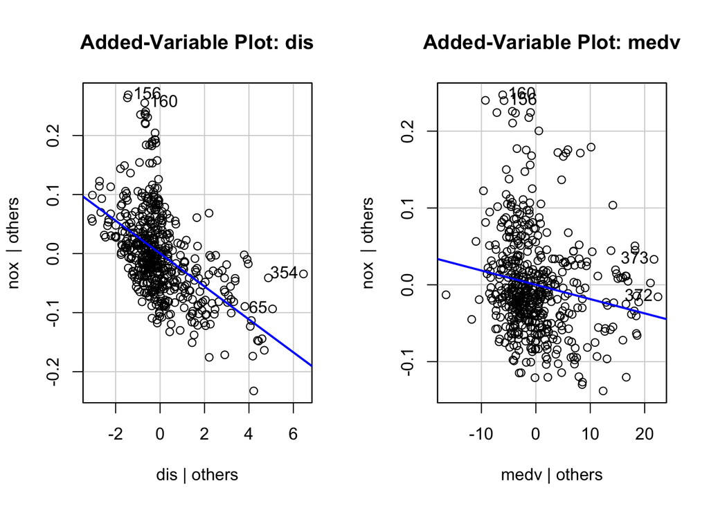

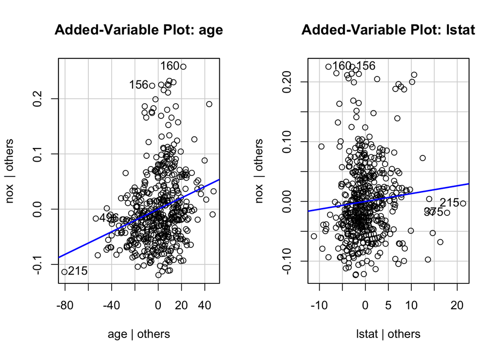

```r
# Partial regression plots
avPlot(lin_model, 'dis')
avPlot(lin_model, 'medv')
avPlot(lin_model, 'age')
avPlot(lin_model, 'lstat')
```

### 1.3.3 Non-linearity

Now that we’ve found the best linear model to use I want to know how good a linear model actually is in modelling the data. It turns out that it is not good. By visually inspecting the difference between our linear line with a LOESS curve (locally estimated scatterplot smoothing) we can see that a non-linear fit may help us arrive at closer predictions of the data.

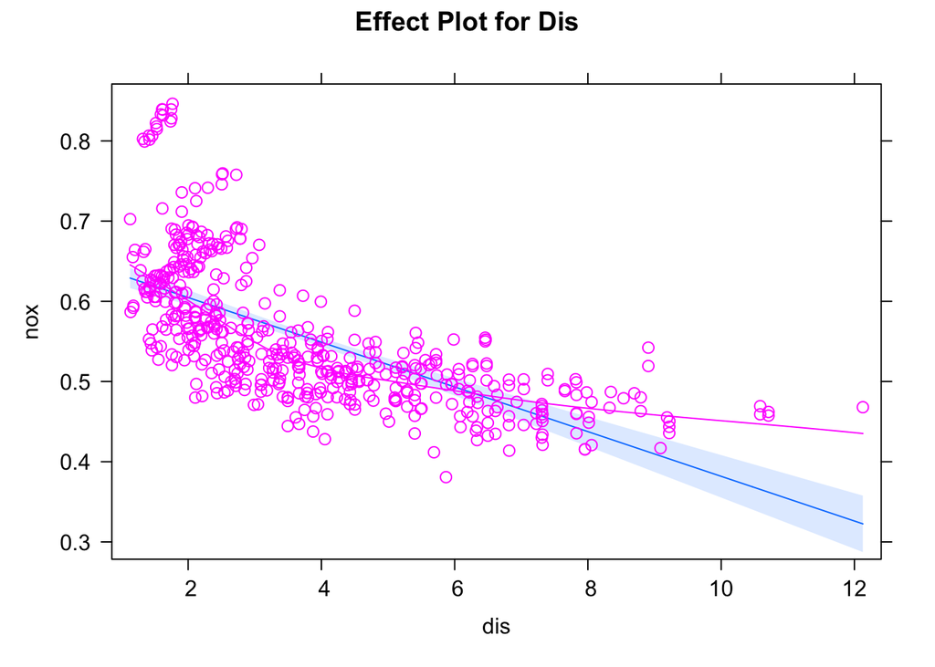

```r
# Effect plot
plot(effect('dis', mod = lin_model, partial.residuals = TRUE), main = 'Effect Plot for Dis')
```

## 1.4 Building Polynomial Models

Next we will consider building polynomial models. Like how we built linear models we can use the same methods. For model selection we will use a backward step-wise method, and for cross-validation we can use K-fold validation (K = 10).

### 1.4.1 Cross-validation

The code for constructing polynomial models is much lengthier than linear models because we need to figure out the degree of power for each input individually.

Below I only showed the code I have written to cross-validate for *dis*. The method for all other variables will be the same except for the formula used.

```r
set.seed(1) # control for random elements

# K-fold with 2 degrees of power
dis_poly_model_train_2 <- train(nox ~ poly(dis, 2) + age + lstat + medv,
                                data = regression_data,
                                method = 'lm',
                                trControl = k_fold)

# K-fold with 3 degrees of power
dis_poly_model_train_3 <- train(nox ~ poly(dis, 3) + age + lstat + medv,
                                data = regression_data,
                                method = 'lm',
                                trControl = k_fold)

# K-fold with 4 degrees of power
dis_poly_model_train_4 <- train(nox ~ poly(dis, 4) + age + lstat + medv,
                                data = regression_data,
                                method = 'lm',
                                trControl = k_fold)

# K-fold with 5 degrees of power
dis_poly_model_train_5 <- train(nox ~ poly(dis, 5) + age + lstat + medv,
                                data = regression_data,
                                method = 'lm',
                                trControl = k_fold)

# K-fold with 6 degrees of power
dis_poly_model_train_6 <- train(nox ~ poly(dis, 6) + age + lstat + medv,
                                data = regression_data,
                                method = 'lm',
                                trControl = k_fold)

# Create blank variable
dis_MSE <- rep(0, 6)

# Assign MSE into lists
dis_MSE[1] <- lin_model_train$results$RMSE
dis_MSE[2] <- dis_poly_model_train_2$results$RMSE
dis_MSE[3] <- dis_poly_model_train_3$results$RMSE
dis_MSE[4] <- dis_poly_model_train_4$results$RMSE
dis_MSE[5] <- dis_poly_model_train_5$results$RMSE
dis_MSE[6] <- dis_poly_model_train_6$results$RMSE
```

### 1.4.2 Validation visuals

The final output can be visualized through a plot of the mean squared errors (MSE) to determine which degree of polynomials produces the least MSE.

For *dis* a degree of 3 is the best. For *age* a degree of 4 is the best. For *medv* a degree of 5 is the best.

For *lstat* it requires a bit more reasoning. Although a degree of 5 is the lowest, a degree of 2 is the close and much simpler. Therefore, a degree of 2 is chosen to be the best.

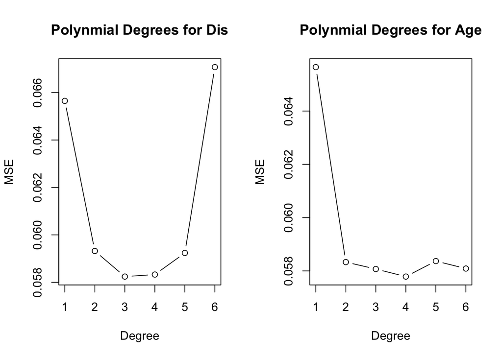

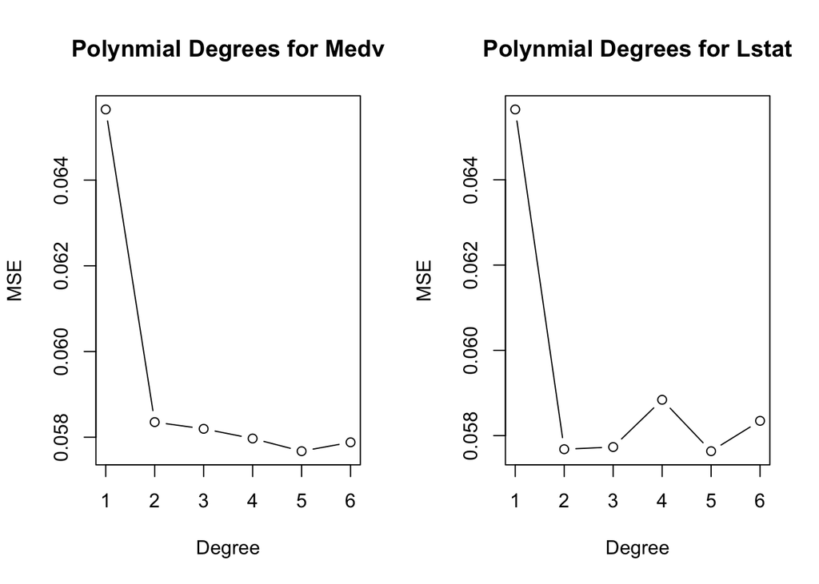

```r
# Plot for dis in degrees based on error
plot(1:6, dis_MSE, type = 'b', ylab = 'MSE', xlab = 'Degree', main = 'Polynmial Degrees for Dis')

# Plot for age in degrees based on error
plot(1:6, age_MSE, type = 'b', ylab = 'MSE', xlab = 'Degree', main = 'Polynmial Degrees for Age')

# Plot for medv in degrees based on error
plot(1:6, medv_MSE, type = 'b', ylab = 'MSE', xlab = 'Degree', main = 'Polynmial Degrees for Medv')

# Plot for lstat in degrees based on error
plot(1:6, lstat_MSE, type = 'b', ylab = 'MSE', xlab = 'Degree', main = 'Polynmial Degrees for Lstat')
```

### 1.4.3 Final polynomial model

The final model can be written as below:

$$y = -1.647(x_{\text{dis}}) + 0.687(x_{\text{dis}})^2 -
0.267(x_{\text{dis}})^3 ... + 0.021(x_{\text{medv}})^5 + 0.555$$

In the form of R code :

```r
poly_model <- lm(nox ~ poly(dis, 3) + poly(age, 4) + poly(lstat, 2) + poly(medv, 5), data = regression_data)
```

### 1.4.4 Model comparisons

```r
# Creating data frame with all accuracy results
lin_poly_comp <- rbind(lin_model_train$results, poly_model$results)

lin_poly_comp
```

```
##   intercept       RMSE  Rsquared        MAE      RMSESD RsquaredSD       MAESD
## 1      TRUE 0.06564923 0.6847712 0.04977613 0.006316137  0.0328884 0.004542681
```

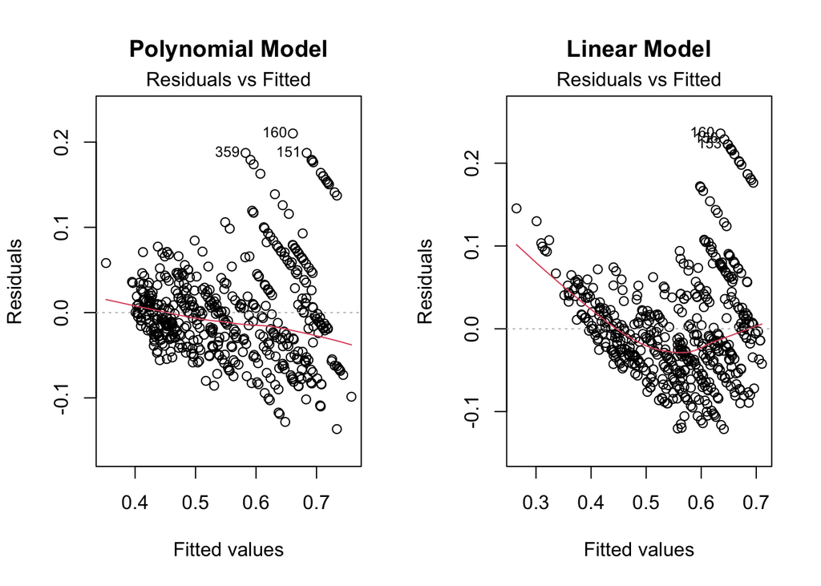

```r
par(mfrow = c(1,2)) # set plot parameters

# Residual plot of linear and polynomial models
plot(poly_model, which = 1, main = 'Polynomial Model')
plot(lin_model, which = 1, main = 'Linear Model')
```

## 1.5 Conclusion

Since all accounts point to our polynomial model providing a more accurate model for prediction we will use it for our final interpretation of the regression problem.

```r
# Construct individual polynomial lines as element for plotting
dis_line <- lm(nox ~ poly(dis, 3), data = regression_data)
age_line <- lm(nox ~ poly(age, 4), data = regression_data)
lstat_line <- lm(nox ~ poly(lstat, 2), data = regression_data)
medv_line <- lm(nox ~ poly(medv, 5), data = regression_data)

attach(regression_data) # attach data

# Plot models
plot(dis, nox)
title("Polynomial Model Fit", outer = T)
lines(sort(regression_data$dis),
      fitted(dis_line)[order(regression_data$dis)],
      lwd = 2, col = 'blue', type = 'l')
plot(age, nox)
lines(sort(regression_data$age),
      fitted(age_line)[order(regression_data$age)],
      lwd = 2, col = 'blue', type = 'l')
plot(lstat, nox)
lines(sort(regression_data$lstat),
      fitted(lstat_line)[order(regression_data$lstat)],
      lwd = 2, col = 'blue', type = 'l')
plot(medv, nox)
lines(sort(regression_data$medv),
      fitted(medv_line)[order(regression_data$medv)],
      lwd = 2, col = 'blue', type = 'l')

detach(regression_data) # detach data
```

A simple description of the relationships show that a greater *dis* or distances from employment centres is correlated to less nitrogen oxide concentrations concentration. This decrease levels out at a distance score of around 6 at 0.438 parts per ten million.

Areas with greater *age* or number of old buildings is correlated exponentially to more nitrogen oxide concentrations.

Areas with greater *lstat* or area with more lower status populations is correlated to more nitrogen oxide concentrations.

[figure not shown]

[figure not shown]

Using statistical learning we have predicted the effect of 4 input variables on nitrogen oxide concentration. All 4 variables provide contributions to either nitrogen oxide increase or decrease. Furthermore, their effects can summed up with the inference that poorer and older areas are more likely to have higher nitrogen oxide concentrations.

Both areas with lower status population and lower house values are related to higher levels of nitrogen oxide. Areas with more old buildings built prior to 1940 have greater concentrations. Even distance from employment centres can be seen as a sign of poverty as employment centres may be purposefully built with the strategy of helping deprived areas, thereby the further away from centres the less deprived, and the less the likelihood for high nitrogen oxide concentrations.

# 2 The Classification Problem

The second problem involves predicting how 4 different factors will affect the whether car seats will put in a good or bad location. The motivation behind answering this problem is to be able to predict probabilities a shop characterized by factors such as sales will place their products.

This is a classification problem because the main measure that we are predicting for is a binary variable with 2 classes.

## 2.1 Load data

Factors:

- *ShelveLoc* - the quality of the shelving location for car seats in each site (*good* or *bad*)
- *Sales* - sales at each location (unit in thousands)
- *CompPrice* - price charged by competitor at each location
- *Price* - price company charges for car seats at each site
- *Age* - average age of the local population

When retrieving our data set we will only select our desired factors. We also data grouped with good or bad shelving locations. Recoding will be conducted to transform good to 1 and bad to 0 so further analysis can be conducted.

```r
# Loading the data
classification_data <- Carseats[Carseats$ShelveLoc == 'Good' | Carseats$ShelveLoc == 'Bad', ] # leave out medium quality shelf location

classification_data <- classification_data[ ,c(1, 2, 6, 7, 8)] # take all rows and only certain columns

# Recode the shelf location variable
classification_data_recode = classification_data

classification_data_recode$ShelveLoc <- as.character(classification_data_recode$ShelveLoc) # recoding requires character

classification_data_recode$ShelveLoc[classification_data_recode$ShelveLoc == 'Good'] <- 1

classification_data_recode$ShelveLoc[classification_data_recode$ShelveLoc == 'Bad'] <- 0

classification_data_recode$ShelveLoc <- as.numeric(classification_data_recode$ShelveLoc) # further analysis requires numeric
```

| ShelveLoc | CompPrice | Price | Sales | Age |
| --- | --- | --- | --- | --- |
| Bad | 138 | 120 | 9.5 | 42 |
| Good | 111 | 83 | 11.22 | 65 |
| Bad | 141 | 128 | 4.15 | 38 |
| Bad | 124 | 72 | 10.81 | 78 |
| Good | 136 | 120 | 11.85 | 67 |
| Bad | 121 | 100 | 9.01 | 26 |
| Good | 117 | 94 | 11.96 | 50 |
| Good | 115 | 86 | 10.96 | 53 |
| Good | 107 | 118 | 11.17 | 52 |
| Good | 118 | 110 | 7.58 | 63 |

[output cut: 171 more lines]

## 2.2 Exploring variables

We are going start off exploring the data through correlations. From the plot we can observe that the only variable with any meaningful correlations is the *Sales* factor. All other variables have correlations nearing 0 and does not contribute to changing shelving location in either direction. This makes our task of building models much simpler as we will only be using one variable.

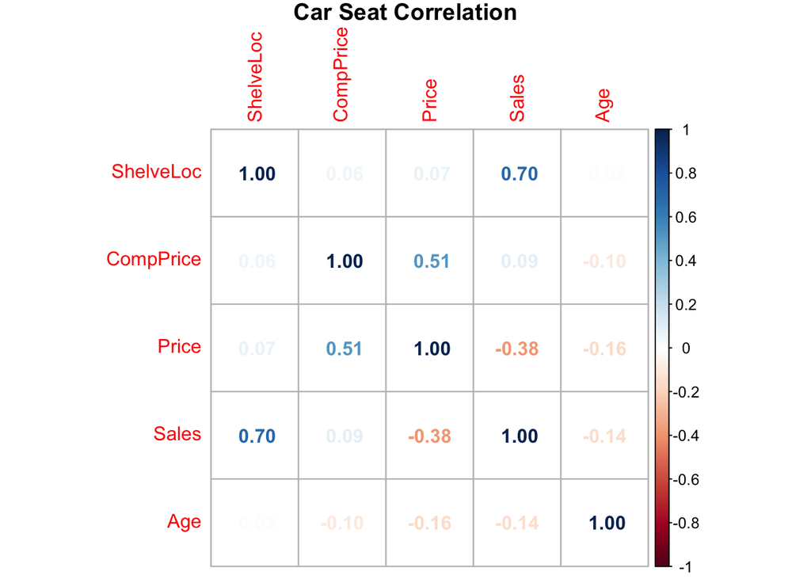

```r
## Correlation plots
corrplot(cor(classification_data_recode),
         method = 'number',
         title = 'Car Seat Correlation',
         mar = c(0,0,1,0))
```

## 2.3 Building Models

### 2.3.1 Logarithmic modelling

We can start the model building process with a linear logarithmic models. Since there is only one input variable there are no alternate variations to the model.

We can assess the accuracy of our model visually through effect plots. Looking at plots of both predicted probabilities and log odds we can see that our current model seems to be a good fit.

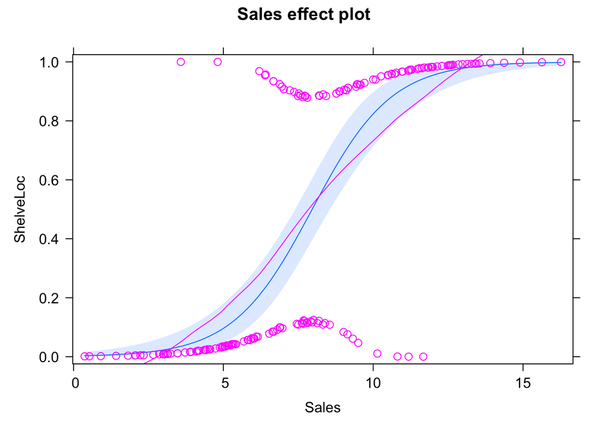

```r
# Building the logarithmic model
log_model <- glm(ShelveLoc ~ Sales, data = classification_data_recode, family = 'binomial')

# Effect plots
par(mfrow = c(1, 2)) # set plot parameters

plot(effect('Sales', mod = log_model, partial.residuals = TRUE), type = 'response') # uses original predicted probabilities
```

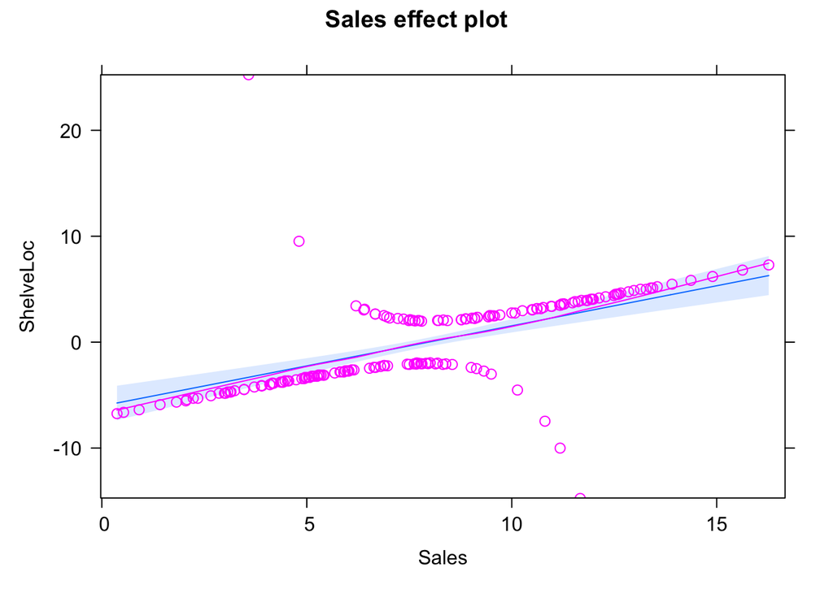

```r
plot(effect('Sales', mod = log_model, partial.residuals = TRUE), type = 'link') # uses log odds to produce straight line
```

### 2.3.2 K-nearest neighbor cross-validation

K-nearest neighbor (KNN) is a non-parametric method that can be used for classification problems. It attempts to establish its own groups by testing data points close to its training data sets. Although we found that our logarithmic model is good, I want to compare it with a non-parametric alternative. To compare KNN and our logarithmic model we will use K-fold cross-validation where K = 10.

```r
set.seed(1) # controls for random elements

# K-fold validation for logarithmic model
log_model_train <- train(Sales ~ ShelveLoc,
                         data = classification_data,
                         method = 'glm',
                         trControl = k_fold)

# K-fold validation for KNN
knn_model_train <- train(Sales ~ ShelveLoc,
                         data = classification_data_recode,
                         method = 'knn',
                         trControl = k_fold,
                         preProcess = c('center', 'scale'))

compare <- rbind(log_model_train$results[2:3], knn_model_train$results[2:3])

compare[-4,][-3,]
```

```
##       RMSE  Rsquared
## 1 2.401733 0.5000885
## 2 2.373892 0.5085504
```

### 2.3.3 Final logarithmic model

Since both models we assessed are so similar we will settle to remain with our logarithmic model where we have a better idea of the structure of our model:

```r
log_model$coefficients
```

```
## (Intercept)       Sales
##  -6.0248276   0.7565743
```

## 2.4 Final Interpretation

Now that we have our model we can start answering our problem. From our model it can be seen that the placing car seats in a good location will only change for units sold. A positive correlation indicates that the greater number of unit sales a location has the higher the chance for the car seat product to be put in a good shelf location.

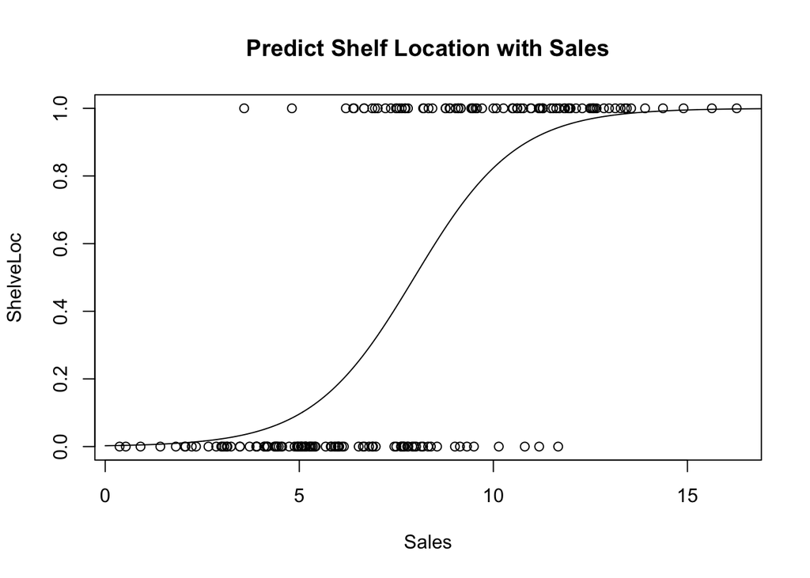

```r
# Acquire plot parameters
x <- seq(from = 0, to = 20, length.out = 1000) # set x parameters

y <- predict(log_model, newdata = data.frame(Sales = c(x)), type = "response") # predict based on model

# Plot logarithmic model
attach(classification_data_recode) # attach data set

plot(ShelveLoc ~ Sales)
title('Predict Shelf Location with Sales')
lines(x, y)
```

It is important to note that we do not know the direction this correlation goes. Perhaps it is not the unit sales that are driving stores to place products in good shelf locations, it may be that because stores are placing car seats in good shelf locations in the first place that unit sales become higher.